# Best Subsets Regression & Cross-Validation

Dylan Maddux

2024-10-09

**Son et al (Journal of Gerontological Nursing, 2003) studied family caregiving in Korea for a sample of n = 100 older adults with dementia. In particular, the researchers were interested in studying the burden on the caregiver, and what factors were most strongly associated with a higher caregiver burden. The response variable, BURDEN, was measured using the Korean Burden Inventory, with scores ranging from 28 to 140, and higher scores indicating a higher burden on the caregiver. The researchers also reported the following potential explanatory variables: CGAGE (the caregiver’s age in years), CGINCOME (the caregiver’s income in Won [Korean currency]), CGDUR (the duration of caregiving in months), ADL (a measure of the older adult’s daily activities, with lower scores indicating more ability to perform activities independently), MEM (a measure of memory and behavior problems, with higher scores indicating more problems), COG (cognitive functioning, with lower scores indicating a greater degree of cognitive impairment), SOCIALSU (perceived social support, with higher values indicating more support)**

```r
library(dplyr)
library(tidyverse)
library(leaps)
library(mdsr)
library(car)
```

**Question 1** Choose a random seed for the set.seed function in R, in order to make your results reproducible, and split the Caregivers data as shown in the surgical survival script, with 70 observations in the training dataset and 30 in the testing dataset.

```r
Caregivers <- read.csv("data/Caregivers.csv")
set.seed(10)
Caregivers$ID = 1:100
train = Caregivers %>% dplyr::sample_frac(0.70)
test = dplyr::anti_join(Caregivers, train, by = 'ID')
```

```r
my.x = train[,1:7]
my.y = train$BURDEN
my.fit1 = leaps(x = my.x, y = my.y, nbest=3)
my.fit2 = leaps(x = my.x, y = my.y, nbest=3, method="r2")
my.fit3 = leaps(x = my.x, y = my.y, nbest=3, method="adjr2")

my.best = data.frame(cbind(my.fit1$which, my.fit1$Cp, my.fit2$r2, my.fit3$adjr2))
colnames(my.best)[8:10] = c("Cp", "R2", "AdjR2")
my.best
```

```
##      X1 X2 X3 X4 X5 X6 X7        Cp        R2     AdjR2
## X1    0  0  0  0  0  0  1 24.136218 0.2457753 0.2346838
## X1.1  0  0  0  0  1  0  0 25.629610 0.2332792 0.2220039
## X1.2  0  0  0  1  0  0  0 37.381813 0.1349414 0.1222199
## X2    0  0  0  0  1  0  1  4.632126 0.4257132 0.4085703
## X2.1  0  0  0  0  0  1  1 17.491342 0.3181123 0.2977574
## X2.2  0  0  0  1  0  0  1 18.874053 0.3065423 0.2858421
## X3    0  1  0  0  1  0  1  4.113062 0.4467917 0.4216459
## X3.1  0  0  0  0  1  1  1  5.230490 0.4374415 0.4118707
## X3.2  0  0  1  0  1  0  1  5.334433 0.4365718 0.4109614
## X4    0  1  0  0  1  1  1  4.276768 0.4621571 0.4290591
## X4.1  0  1  1  0  1  0  1  4.854762 0.4573207 0.4239250
## X4.2  0  1  0  1  1  0  1  5.076864 0.4554622 0.4219522
## X5    0  1  1  0  1  1  1  4.609874 0.4761050 0.4351757
## X5.1  1  1  0  0  1  1  1  5.547498 0.4682594 0.4267171
## X5.2  0  1  1  1  1  0  1  5.576243 0.4680188 0.4264578
## X6    1  1  1  0  1  1  1  6.158064 0.4798856 0.4303509
## X6.1  0  1  1  1  1  1  1  6.515648 0.4768935 0.4270738
## X6.2  1  1  1  1  1  0  1  7.093143 0.4720612 0.4217813
## X7    1  1  1  1  1  1  1  8.000000 0.4812082 0.4226349
```

**Question 3** Check the appropriate diagnostic plots (residuals vs. fitted values, and normal Q-Q plot of residuals) and the VIF values for your model on the training data. Are any problems indicated?

```r
model1 <-lm(BURDEN~CGDUR+MEM+SOCIALSU, train)
summary(model1)
```

```
##
## Call:
## lm(formula = BURDEN ~ CGDUR + MEM + SOCIALSU, data = train)
##
## Residuals:
##      Min       1Q   Median       3Q      Max
## -30.1325  -8.2113   0.4177   8.0963  30.4742
##
## Coefficients:
##              Estimate Std. Error t value Pr(>|t|)
## (Intercept) 118.88676   14.62595   8.128 1.56e-11 ***
## CGDUR         0.07563    0.06706   1.128    0.263
## MEM           0.49264    0.11450   4.303 5.71e-05 ***
## SOCIALSU     -0.49189    0.10285  -4.783 1.01e-05 ***
## ---
## Signif. codes:  0 '***' 0.001 '**' 0.01 '*' 0.05 '.' 0.1 ' ' 1
##
## Residual standard error: 14.44 on 66 degrees of freedom
## Multiple R-squared:  0.4366, Adjusted R-squared:  0.411
## F-statistic: 17.05 on 3 and 66 DF,  p-value: 2.644e-08
```

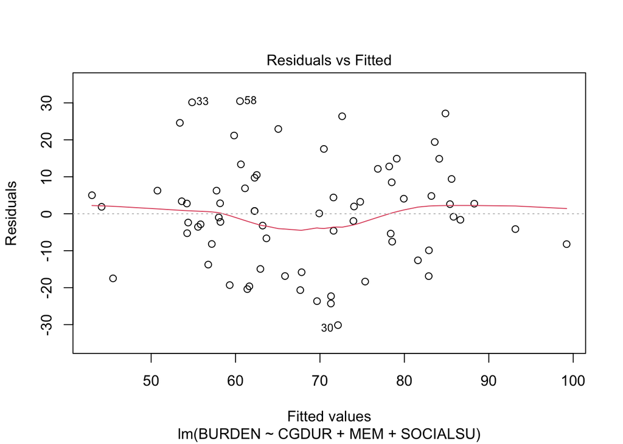

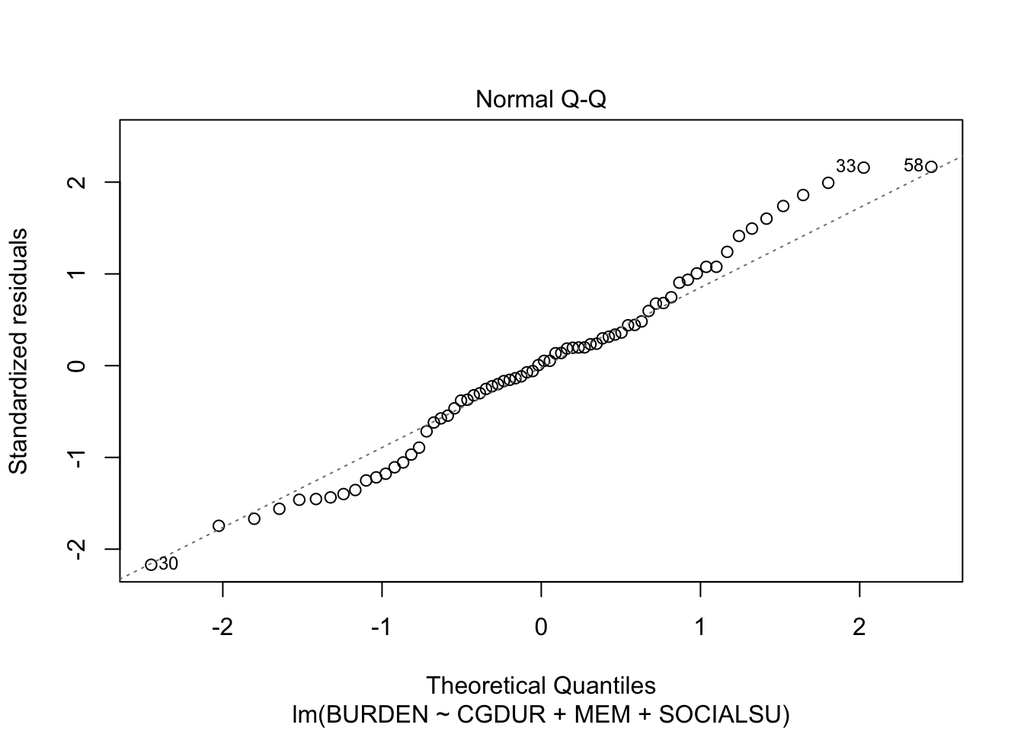

```r
plot(model1, 1:2)
```

```r
vif(model1)
```

```
##    CGDUR      MEM SOCIALSU
## 1.035652 1.052088 1.017095
```

Checking the appropriate diagnostic plots and VIF values, there are no salient problems indicated. The residuals’ distribution appears homoscedastic (although a few outliers exist), the Q-Q plot appears to be relatively normal (albeit with a slight light-tailed distribution), and the VIF values are low and far under 5.

**Question 4** Apply your model to your testing dataset to get fitted $\widehat{Y}$ values for the 30 testing observations, and use the fitted values to calculate the cross-validation correlation, testing R², and shrinkage. Briefly comment on how well your model generalized to the testing data, and the implications for using the model to predict the burden of caregiving for other adults in Korea.

```r
mynewdata = dplyr::select(test, CGDUR, MEM, SOCIALSU)
my.yhat = predict(model1, newdata = mynewdata, type = "response")
my.yhat
```

```
##        1        2        3        4        5        6        7        8
## 63.22963 73.42854 62.44257 47.86705 92.12758 69.19236 55.36604 78.91632
##        9       10       11       12       13       14       15       16
## 75.39240 66.73331 78.87598 80.34050 71.14770 67.66336 54.75983 78.46997
##       17       18       19       20       21       22       23       24
## 72.58825 67.20991 49.11741 54.52682 69.56663 68.16865 69.62721 78.91334
##       25       26       27       28       29       30
## 81.45125 78.41475 95.98536 85.16967 78.72811 78.07009
```

```r
cor(test$BURDEN, my.yhat)
```

```
## [1] 0.6690728
```

```r
cor(test$BURDEN, my.yhat)^2
```

```
## [1] 0.4476584
```

```r
43.66-44.77
```

```
## [1] -1.11
```

Our model generalized well to the testing data since the correlation coefficient and R² values were moderately large, and our shrinkage was actually negative. Using the model to predict the burden of caregiving for other adults in Korea could be a useful baseline tool to assess estimates, but the model is not perfect and its predictions should be considered in conjunction with other contextual elements not included in this particular model (e.g., individual psychological elements of caregiver, strength of relationship between caregiver and patient).

**Question 5** Explain why the results of this model should not be used to test hypotheses about the importance of these seven predictors in contributing to caregiver burden in Korea, even if the model may indeed be used to predict caregiver burden.

Training/testing modeling is used for predicting how well a model generalizes to predict unseen data, whereas predictive modeling is used to test hypotheses about the relationship between specific variables. Even if the model derived from the training data generalizes well to the testing data and therefore predicts a certain relationship, the sample used is incomplete, meaning that inferences cannot be applied to the full data set.